# Uso de API DE Covid con Pandas

## Tiempo real Colombia

Basicamente es repetir todos los pasos que hemos realizado con España, pero con una URL distinta. [URL Colombia](https://api.covid19api.com/country/colombia/status/confirmed/live)

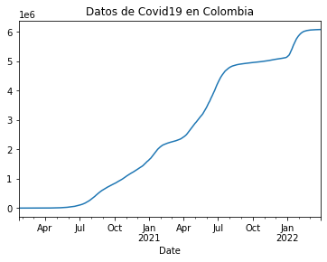

```python
url_co = 'https://api.covid19api.com/country/colombia/status/confirmed/live'
df_co = pd.read_json(url_co)
df_co.set_index('Date')['Cases'].plot(title="Datos de Covid19 en Colombia")
```

## Comparativa España-Colombia

En este apartado, lo básico es la concanetación de datos. Que sirve para poder comparar los datos y juntar las cadenas de caracteres.

`casos_es = df_es.set_index('Date')['Cases']` `casos_co = df_co.set_index('Date')['Cases']` `casos_co`

```python
casos_es = df_es.set_index('Date')['Cases']
casos_co = df_co.set_index('Date')['Cases']
```

```python
casos_es
```

```
Date
2020-01-22 00:00:00+00:00           0
2020-01-23 00:00:00+00:00           0
2020-01-24 00:00:00+00:00           0
2020-01-25 00:00:00+00:00           0
2020-01-26 00:00:00+00:00           0
                               ...
2022-03-26 00:00:00+00:00    11451676
2022-03-27 00:00:00+00:00    11451676
2022-03-28 00:00:00+00:00    11451676
2022-03-29 00:00:00+00:00    11508309
2022-03-30 00:00:00+00:00    11508309
Name: Cases, Length: 799, dtype: int64
```

```python
casos_co
```

```
Date
2020-01-22 00:00:00+00:00          0
2020-01-23 00:00:00+00:00          0
2020-01-24 00:00:00+00:00          0
2020-01-25 00:00:00+00:00          0
2020-01-26 00:00:00+00:00          0
                              ...
2022-03-26 00:00:00+00:00    6083291
2022-03-27 00:00:00+00:00    6083643
2022-03-28 00:00:00+00:00    6083939
2022-03-29 00:00:00+00:00    6084240
2022-03-30 00:00:00+00:00    6084551
Name: Cases, Length: 799, dtype: int64
```

```python
pd.concat([casos_es,casos_co],axis=1)
```

| Date | Cases | Cases |
| --- | --- | --- |
| 2020-01-22 00:00:00+00:00 | 0 | 0 |
| 2020-01-23 00:00:00+00:00 | 0 | 0 |
| 2020-01-24 00:00:00+00:00 | 0 | 0 |
| 2020-01-25 00:00:00+00:00 | 0 | 0 |
| 2020-01-26 00:00:00+00:00 | 0 | 0 |
| ... | ... | ... |
| 2022-03-26 00:00:00+00:00 | 11451676 | 6083291 |
| 2022-03-27 00:00:00+00:00 | 11451676 | 6083643 |
| 2022-03-28 00:00:00+00:00 | 11451676 | 6083939 |
| 2022-03-29 00:00:00+00:00 | 11508309 | 6084240 |
| 2022-03-30 00:00:00+00:00 | 11508309 | 6084551 |

799 rows × 2 columns

```python
vs = pd.concat([casos_es,casos_co],axis=1)
vs
```

| Date | Cases | Cases |
| --- | --- | --- |
| 2020-01-22 00:00:00+00:00 | 0 | 0 |
| 2020-01-23 00:00:00+00:00 | 0 | 0 |
| 2020-01-24 00:00:00+00:00 | 0 | 0 |
| 2020-01-25 00:00:00+00:00 | 0 | 0 |
| 2020-01-26 00:00:00+00:00 | 0 | 0 |
| ... | ... | ... |
| 2022-03-26 00:00:00+00:00 | 11451676 | 6083291 |
| 2022-03-27 00:00:00+00:00 | 11451676 | 6083643 |
| 2022-03-28 00:00:00+00:00 | 11451676 | 6083939 |
| 2022-03-29 00:00:00+00:00 | 11508309 | 6084240 |
| 2022-03-30 00:00:00+00:00 | 11508309 | 6084551 |

799 rows × 2 columns

Además, podemos poner nombre a las columnas para diferenciarlas, en el objeto vs.columns ponemos entre corchetes como queremos que se llamen. `vs.columns = ['España','Colombia']` y también podemos definir las comparaciones: `vs.plot(title="España VS Colombia")`

```python
vs.columns = ['España','Colombia']
vs
```

| Date | España | Colombia |
| --- | --- | --- |
| 2020-01-22 00:00:00+00:00 | 0 | 0 |
| 2020-01-23 00:00:00+00:00 | 0 | 0 |
| 2020-01-24 00:00:00+00:00 | 0 | 0 |
| 2020-01-25 00:00:00+00:00 | 0 | 0 |
| 2020-01-26 00:00:00+00:00 | 0 | 0 |
| ... | ... | ... |
| 2022-03-26 00:00:00+00:00 | 11451676 | 6083291 |
| 2022-03-27 00:00:00+00:00 | 11451676 | 6083643 |
| 2022-03-28 00:00:00+00:00 | 11451676 | 6083939 |
| 2022-03-29 00:00:00+00:00 | 11508309 | 6084240 |
| 2022-03-30 00:00:00+00:00 | 11508309 | 6084551 |

799 rows × 2 columns

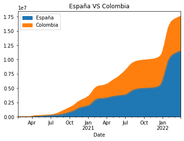

```python
vs.plot(title="España VS Colombia",kind='area')
```